# Growth Comparisons

Sarai Hutchinson

2025-09-01

```r
library(tidyverse)
library(viridis)
library(janitor)
library(lme4)

# Color palettes
okabe_ito <- c("#009E73", "#D55E00", "#E69F00", "#56B4E9", "#F0E442", "#0072B2", "#CC79A7")
viridis_palette <- viridis(8)
```

### 1. Load & Clean

```r
surv <- readr::read_csv("C:\\Users\\sarai\\OneDrive\\Email attachments\\Documents\\UVI\\Thesis.Work\\SargMangs\\OutputData\\survivors_tp0-tp6.csv",
                        guess_max = 10000, show_col_types = FALSE) %>%
  clean_names()

surv <- surv%>%
  mutate(
treatment_name = factor(
      treatment_name,
      levels = c("Soil", "Crushed glass", "25% SG", "75% SG", "100% Sargassum (SG)"))) #ordered it so that it goes from least Sargassum to most Sargassum additions

# Coerce to numeric safely
num_cols <- c("rhma_height_1","rhma_height_2","rhma_epi_length",
              "lara_height_1","lara_height_2","number_branches")
num_cols <- intersect(num_cols, names(surv))

surv <- surv %>%
  mutate(across(all_of(num_cols), ~ suppressWarnings(as.numeric(.x))))

# Ensure time_period is numeric
surv <- surv %>%
  mutate(across(all_of(num_cols), ~ suppressWarnings(as.numeric(.x))),
         time_period = suppressWarnings(as.numeric(time_period)),
         monitor_date = suppressWarnings(ymd(date_monitored)),
         uploaded_date = suppressWarnings(ymd(date_uploaded)))

# ----- define shapes for each Treatment_Name (match your factor levels) -----
shape_vals <- c(
  "Soil"               = 0, # open square
  "Crushed glass" = 17, # filled triangle
  "100% Sargassum (SG)"= 15, # filled square
  "25% SG"       = 18, # filled diamond
  "75% SG"       = 8   # asterick
)

# Uses your okabe_ito vector (7 colors). Pick 5 distinct hues.
color_vals <- c(
  "Soil"                = okabe_ito[1], # green  (#009E73)
  "Crushed glass"       = okabe_ito[6], # blue   (#0072B2)
  "25% SG"              = okabe_ito[3], # orange (#E69F00)
  "75% SG"              = okabe_ito[2], # vermil (#D55E00)
  "100% Sargassum (SG)" = okabe_ito[7]  # purple (#CC79A7)
)
```

```r
# Duplicates per plant-time
dups <- surv %>%
  count(species, treatment_name, prop_id, time_period, sort = TRUE) %>%
  filter(n > 1)
dups %>% print(n = 40)
```

```
## # A tibble: 0 × 5
## # ℹ 5 variables: species <chr>, treatment_name <fct>, prop_id <chr>,
## #   time_period <dbl>, n <int>
```

```r
# Temporary total heights to check non-positive values
surv_chk <- surv %>%
  mutate(
    total_height_substrate_cm = case_when(
      species == "RHMA" ~ rhma_height_1 + rhma_epi_length,
      species == "LARA" ~ lara_height_1,
      TRUE ~ NA_real_
    ),
    total_height_pot_cm = case_when(
      species == "RHMA" ~ rhma_height_2 + rhma_epi_length,
      species == "LARA" ~ lara_height_2,
      TRUE ~ NA_real_
    ),
    total_height_mean_cm = {
      m <- cbind(total_height_substrate_cm, total_height_pot_cm)
      x <- rowMeans(m, na.rm = TRUE)
      ifelse(is.nan(x), NA_real_, x)
    }
  )

surv_chk %>%
  filter(!is.na(total_height_mean_cm), total_height_mean_cm <= 0) %>%
  count(species, treatment_name, time_period, sort = TRUE) %>%
  print(n = 40)
```

```
## # A tibble: 13 × 4
##    species treatment_name      time_period     n
##    <chr>   <fct>                     <dbl> <int>
##  1 LARA    Soil                          0    35
##  2 LARA    Crushed glass                 0    17
##  3 LARA    75% SG                        0    17
##  4 LARA    25% SG                        0     6
##  5 LARA    75% SG                        6     3
##  6 LARA    75% SG                        1     2
##  7 LARA    Soil                          2     1
##  8 LARA    Crushed glass                 3     1
##  9 LARA    Crushed glass                 6     1
## 10 LARA    75% SG                        2     1
## 11 LARA    75% SG                        3     1
## 12 LARA    75% SG                        4     1
## 13 LARA    100% Sargassum (SG)           0     1
```

### 2. Total Heights (substrate, pot, mean, change between tp0 and tp6)

```r
surv <- surv %>%
  mutate(
    total_height_substrate_cm = case_when(
      species == "RHMA" ~ rhma_height_1 + rhma_epi_length,
      species == "LARA" ~ lara_height_1,
      TRUE ~ NA_real_
    ),
    total_height_pot_cm = case_when(
      species == "RHMA" ~ rhma_height_2 + rhma_epi_length,
      species == "LARA" ~ lara_height_2,
      TRUE ~ NA_real_
    ),
    total_height_mean_cm = {
      m <- cbind(total_height_substrate_cm, total_height_pot_cm)
      x <- rowMeans(m, na.rm = TRUE)
      ifelse(is.nan(x), NA_real_, x)
    }
  )

surv_use <- surv %>% filter(!is.na(time_period))

# --- Calculate change between TP0 and TP6 ---
height_change <- surv_use %>%
  filter(time_period %in% c(0, 6)) %>%
  select(prop_id, species, treatment_name, time_period, total_height_mean_cm) %>%
  pivot_wider(
    names_from = time_period,
    values_from = total_height_mean_cm,
    names_prefix = "TP"
  ) %>%
  mutate(
    height_change_tp0_tp6 = TP6 - TP0
  )

# 2) otherwise, keep as-is (assumes one row per prop_id × time_period)
surv_use <- surv %>% filter(time_period %in% c(0, 6))

height_change_tp0_tp6 <- surv_use %>%
  select(prop_id, species, treatment_name, time_period,
         total_height_substrate_cm, total_height_pot_cm) %>%
  pivot_wider(
    names_from  = time_period,
    values_from = c(total_height_substrate_cm, total_height_pot_cm),
    names_glue  = "{.value}_TP{time_period}"
  ) %>%
  mutate(
    d_substrate_cm = total_height_substrate_cm_TP6 - total_height_substrate_cm_TP0,
    d_pot_cm       = total_height_pot_cm_TP6       - total_height_pot_cm_TP0
  )

delta_summary <- height_change_tp0_tp6 %>%
  group_by(species, treatment_name) %>%
  summarise(
    n              = dplyr::n(),
    mean_d_sub_cm  = mean(d_substrate_cm, na.rm = TRUE),
    sd_d_sub_cm    = sd(d_substrate_cm,   na.rm = TRUE),
    mean_d_pot_cm  = mean(d_pot_cm,       na.rm = TRUE),
    sd_d_pot_cm    = sd(d_pot_cm,         na.rm = TRUE),
    .groups = "drop"
  )
```

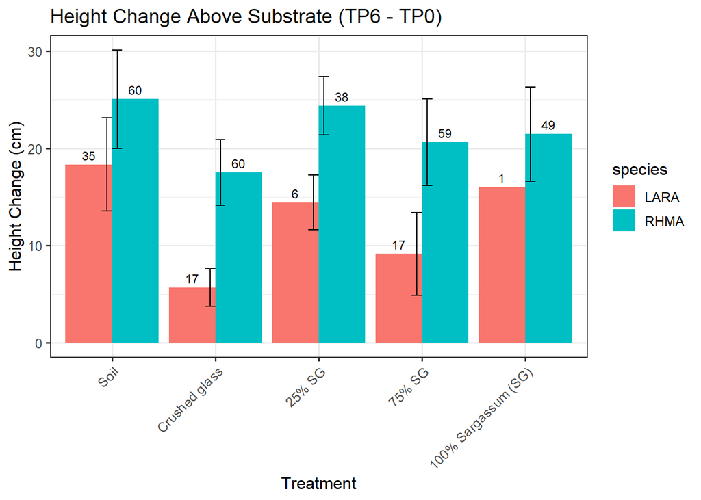

```r
# Substrate
ggplot(delta_summary,
       aes(x = treatment_name, y = mean_d_sub_cm,
           fill = species)) +
  geom_col(position = position_dodge()) +
  geom_errorbar(aes(ymin = mean_d_sub_cm - sd_d_sub_cm,
                    ymax = mean_d_sub_cm + sd_d_sub_cm),
                width = 0.2,
                position = position_dodge()) +
  geom_text(aes(label = n),
            position = position_dodge(width = 0.9),
            vjust = -0.5, size = 3) +
  labs(
    title = "Height Change Above Substrate (TP6 - TP0)",
    x = "Treatment",
    y = "Height Change (cm)"
  ) +
  theme_bw(base_size = 12) +
  theme(axis.text.x = element_text(angle = 45, hjust = 1))
```

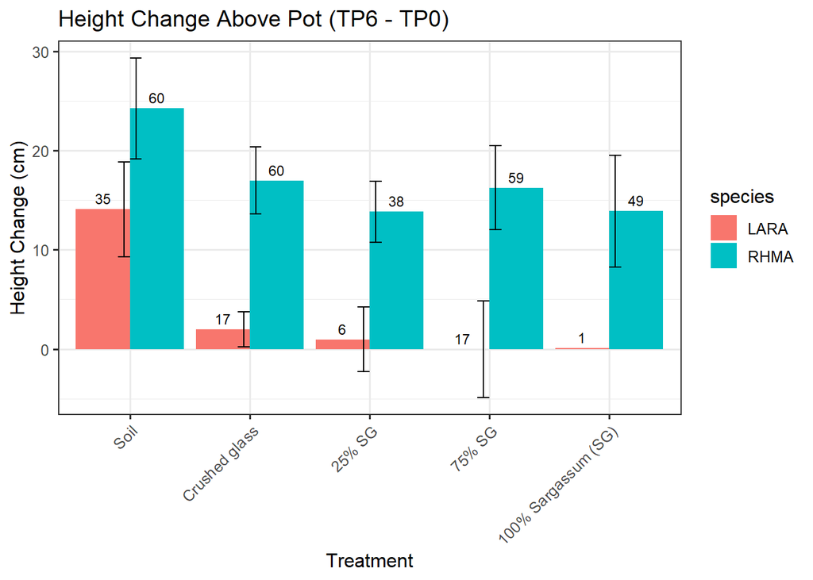

```r
# Pot
ggplot(delta_summary,
       aes(x = treatment_name, y = mean_d_pot_cm,
           fill = species)) +
  geom_col(position = position_dodge()) +
  geom_errorbar(aes(ymin = mean_d_pot_cm - sd_d_pot_cm,
                    ymax = mean_d_pot_cm + sd_d_pot_cm),
                width = 0.2,
                position = position_dodge()) +
  geom_text(aes(label = n),
            position = position_dodge(width = 0.9),
            vjust = -0.5, size = 3) +
  labs(
    title = "Height Change Above Pot (TP6 - TP0)",
    x = "Treatment",
    y = "Height Change (cm)"
  ) +
  theme_bw(base_size = 12) +
  theme(axis.text.x = element_text(angle = 45, hjust = 1))
```

### Show Height changes overtime

## Step 1. Compute stepwise changes per propagule

```r
library(dplyr)

# Start from your surv dataset with heights already calculated and it should have all the time_periods and not just tp0 and tp6 like surv_use
height_steps <- surv %>%
  filter(!is.na(time_period)) %>%
  select(prop_id, species, treatment_name, time_period,
         total_height_substrate_cm, total_height_pot_cm) %>%
  arrange(prop_id, time_period) %>%
  group_by(prop_id, species, treatment_name) %>%
  mutate(
    d_sub_cm = total_height_substrate_cm - lag(total_height_substrate_cm),
    d_pot_cm = total_height_pot_cm       - lag(total_height_pot_cm),
    interval_start = lag(time_period),
    interval_end   = time_period
  ) %>%
  ungroup() %>%
  filter(!is.na(d_sub_cm), !is.na(d_pot_cm)) %>%
  mutate(time_point = interval_end)   # assign to the ending TP
```

## Step 2. Summarise by species × treatment × time point

```r
# Summarise by species × treatment × time point
step_summary <- height_steps %>%
  group_by(species, treatment_name, time_point) %>%
  summarise(
    n              = n(),
    mean_d_sub_cm  = mean(d_sub_cm, na.rm = TRUE),
    sd_d_sub_cm    = sd(d_sub_cm,   na.rm = TRUE),
    mean_d_pot_cm  = mean(d_pot_cm, na.rm = TRUE),
    sd_d_pot_cm    = sd(d_pot_cm,   na.rm = TRUE),
    .groups = "drop"
  )
```

## Step 3. Line plot

To plot as a line graph across intervals, add a baseline and reshape to long format:

```r
library(tidyr)
library(ggplot2)

# Add baseline at TP0 (0 change)
baseline <- step_summary %>%
  distinct(species, treatment_name) %>%
  mutate(time_point = 0,
         n = NA,
         mean_d_sub_cm = 0,
         sd_d_sub_cm   = 0,
         mean_d_pot_cm = 0,
         sd_d_pot_cm   = 0)

step_summary <- bind_rows(baseline, step_summary) %>%
  arrange(species, treatment_name, time_point)


plot_step <- step_summary %>%
  pivot_longer(
    cols = c(mean_d_sub_cm, mean_d_pot_cm),
    names_to = "metric",
    values_to = "mean_change"
  ) %>%
  mutate(
    sd = dplyr::case_when(
      metric == "mean_d_sub_cm" ~ sd_d_sub_cm,
      metric == "mean_d_pot_cm" ~ sd_d_pot_cm
    ),
    metric = dplyr::recode(metric,
                    "mean_d_sub_cm" = "Above Substrate",
                    "mean_d_pot_cm" = "Above Pot"),
    interval = factor(time_point,
                      levels = unique(height_steps$time_point)) # keeps order TP0→TP6
  )
```

Line plot: same axes per species, separate lines per treatment

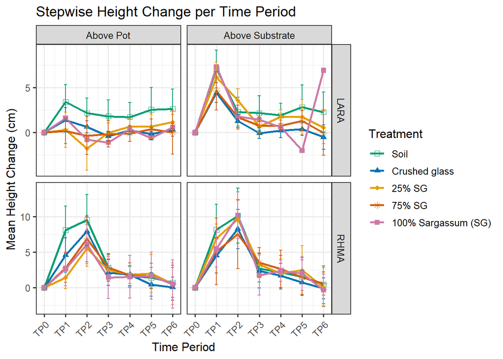

```r
ggplot(plot_step,
       aes(x = time_point, y = mean_change,
           color = treatment_name, shape = treatment_name,
           group = treatment_name)) +
  geom_line(linewidth = 1) +
  geom_point(size = 2) +
  geom_errorbar(aes(ymin = mean_change - sd,
                    ymax = mean_change + sd),
                width = 0.15) +
    # geom_text(aes(label = n),
    #         position = position_dodge(width = 0.9),
    #         vjust = -0.5, size = 3) +
  facet_grid(rows = vars(species), cols = vars(metric), scales = "free_y") +
  scale_color_manual(values = color_vals, name = "Treatment") +
  scale_shape_manual(values = shape_vals, name = "Treatment") +
  scale_x_continuous(breaks = 0:6, labels = paste0("TP", 0:6)) +
  labs(
    title = "Stepwise Height Change per Time Period",
    x = "Time Period",
    y = "Mean Height Change (cm)"
  ) +
  theme_bw(base_size = 12) +
  theme(axis.text.x = element_text(angle = 45, hjust = 1))
```

Everything After this Point is questionable!!

### 3. Compute AGR & RGR (per plant)

```r
by_prop <- surv %>%
  group_by(species, treatment_name, prop_id) %>%
  arrange(time_period, .by_group = TRUE) %>%
  mutate(
    dt = time_period - lag(time_period),
    h_mean = total_height_mean_cm,
    h_mean_lag = lag(h_mean),
    h_mean_pos = ifelse(h_mean > 0, h_mean, NA_real_),
    h_mean_pos_lag = ifelse(h_mean_lag > 0, h_mean_lag, NA_real_),
    AGR = (h_mean - h_mean_lag) / dt,
    RGR = (log(h_mean_pos) - log(h_mean_pos_lag)) / dt
  ) %>%
  ungroup()
```

### 4. Summarize by Species × Substrate × Time_Period

```r
growth_summary <- by_prop %>%
  group_by(species, treatment_name, time_period) %>%
  summarise(
    n_records = n(),
    mean_total_height_cm = mean(total_height_mean_cm, na.rm = TRUE),
    sd_total_height_cm   = sd(total_height_mean_cm, na.rm = TRUE),
    mean_branches        = mean(number_branches, na.rm = TRUE),
    sd_branches          = sd(number_branches, na.rm = TRUE),
    mean_AGR_cm_per_TP   = mean(AGR, na.rm = TRUE),
    sd_AGR_cm_per_TP     = sd(AGR, na.rm = TRUE),
    mean_RGR_per_TP      = mean(RGR, na.rm = TRUE),
    sd_RGR_per_TP        = sd(RGR, na.rm = TRUE),
    .groups = "drop"
  ) %>%
  arrange(species, treatment_name, time_period)

print(growth_summary, n = 30)
```

```
## # A tibble: 70 × 12
##    species treatment_name      time_period n_records mean_total_height_cm
##    <chr>   <fct>                     <dbl>     <int>                <dbl>
##  1 LARA    Soil                          0        35                 0
##  2 LARA    Soil                          1        35                 5.22
##  3 LARA    Soil                          2        35                 7.28
##  4 LARA    Soil                          3        35                 9.27
##  5 LARA    Soil                          4        35                11.1
##  6 LARA    Soil                          5        35                13.8
##  7 LARA    Soil                          6        35                16.2
##  8 LARA    Crushed glass                 0        17                 0
##  9 LARA    Crushed glass                 1        17                 2.90
## 10 LARA    Crushed glass                 2        17                 3.85
## 11 LARA    Crushed glass                 3        17                 3.61
## 12 LARA    Crushed glass                 4        17                 3.84
```

[output cut: 22 more lines]

### 5. Export (optional)

```r
# Save to CSV if you want a table
readr::write_csv(growth_summary,
  "C:/Users/sarai/OneDrive/Email attachments/Documents/UVI/Thesis.Work/SargMangs/OutputData/growth_summary_by_species_substrate_TP.csv")
```

### 1) Mean Total Height (cm) — line + ribbon (± SD), faceted by species

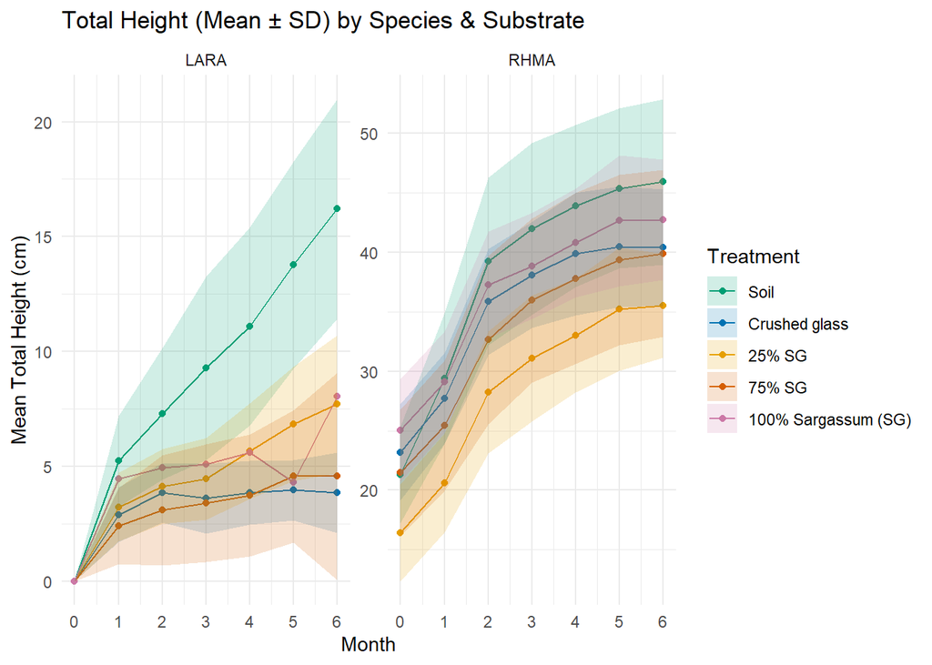

```r
ggplot(growth_summary,
       aes(x = time_period, y = mean_total_height_cm,
           color = treatment_name, group = treatment_name)) +
  geom_line() +
  geom_point() +
  geom_ribbon(aes(ymin = mean_total_height_cm - sd_total_height_cm,
                  ymax = mean_total_height_cm + sd_total_height_cm,
                  fill = treatment_name),
              alpha = 0.18, color = NA) +
  facet_wrap(~ species, scales = "free_y") +
  labs(x = "Month", y = "Mean Total Height (cm)",
       title = "Total Height (Mean ± SD) by Species & Substrate") +
    scale_color_manual(values = color_vals, name = "Treatment") +
  scale_fill_manual(values = color_vals, name = "Treatment") +
  scale_shape_manual(values = shape_vals, name = "Treatment") +
  scale_x_continuous(breaks = sort(unique(growth_summary$time_period))) +
  theme_minimal()
```

### 2) Mean AGR (cm per TP) — line + ribbon (± SD), faceted by species

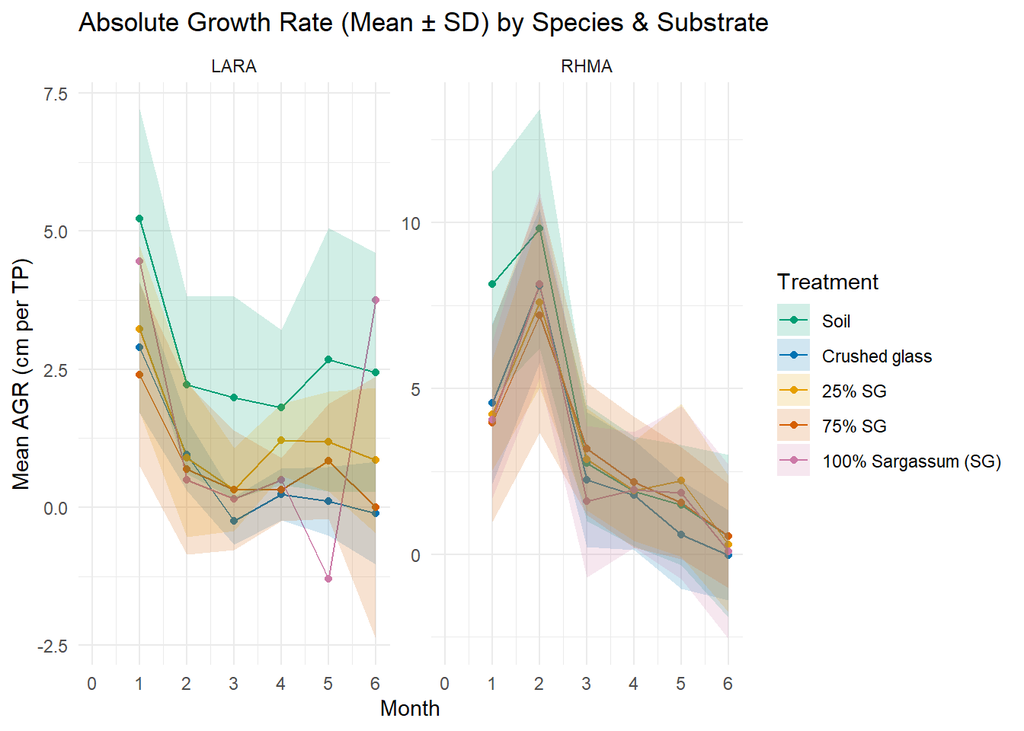

```r
ggplot(growth_summary,
       aes(x = time_period, y = mean_AGR_cm_per_TP,
           color = treatment_name, group = treatment_name)) +
  geom_line() +
  geom_point() +
  geom_ribbon(aes(ymin = mean_AGR_cm_per_TP - sd_AGR_cm_per_TP,
                  ymax = mean_AGR_cm_per_TP + sd_AGR_cm_per_TP,
                  fill = treatment_name),
              alpha = 0.18, color = NA) +
  facet_wrap(~ species, scales = "free_y") +
  labs(x = "Month", y = "Mean AGR (cm per TP)",
       title = "Absolute Growth Rate (Mean ± SD) by Species & Substrate") +
  scale_color_manual(values = color_vals, name = "Treatment") +
  scale_fill_manual(values = color_vals, name = "Treatment") +
  scale_shape_manual(values = shape_vals, name = "Treatment") +
  scale_x_continuous(breaks = sort(unique(growth_summary$time_period))) +
  theme_minimal()
```

### 3) Mean RGR (1 per TP) — line + ribbon (± SD), faceted by species

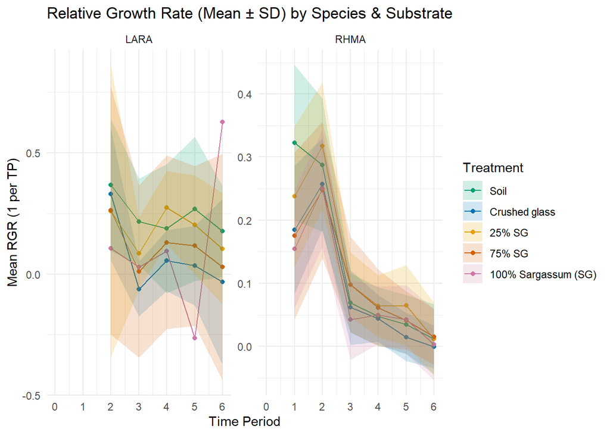

```r
ggplot(growth_summary,
       aes(x = time_period, y = mean_RGR_per_TP,
           color = treatment_name, group = treatment_name)) +
  geom_line() +
  geom_point() +
  geom_ribbon(aes(ymin = mean_RGR_per_TP - sd_RGR_per_TP,
                  ymax = mean_RGR_per_TP + sd_RGR_per_TP,
                  fill = treatment_name),
              alpha = 0.18, color = NA) +
  facet_wrap(~ species, scales = "free_y") +
  labs(x = "Time Period", y = "Mean RGR (1 per TP)",
       title = "Relative Growth Rate (Mean ± SD) by Species & Substrate") +
  scale_color_manual(values = color_vals, name = "Treatment") +
  scale_fill_manual(values = color_vals, name = "Treatment") +
  scale_shape_manual(values = shape_vals, name = "Treatment") +
  scale_x_continuous(breaks = sort(unique(growth_summary$time_period))) +
  theme_minimal()
```

See where RGR is negative and how many plants contribute

```r
neg_rgr <- growth_summary %>%
  filter(mean_RGR_per_TP < 0) %>%
  arrange(species, treatment_name, time_period) %>%
  select(species, treatment_name, time_period,
         n_records, mean_RGR_per_TP, sd_RGR_per_TP)
neg_rgr
```

```
## # A tibble: 4 × 6
##   species treatment_name     time_period n_records mean_RGR_per_TP sd_RGR_per_TP
##   <chr>   <fct>                    <dbl>     <int>           <dbl>         <dbl>
## 1 LARA    Crushed glass                3        17       -0.0624          0.113
## 2 LARA    Crushed glass                6        17       -0.0333          0.342
## 3 LARA    100% Sargassum (S…           5         1       -0.264          NA
## 4 RHMA    Crushed glass                6        60       -0.000413        0.0339
```

If you didn’t save contributor counts for RGR, add them:

```r
# Rebuild contributor counts for RGR if missing
by_prop_counts <- by_prop %>%
  group_by(species, treatment_name, time_period) %>%
  summarise(n_RGR = sum(!is.na(RGR)), .groups = "drop")

growth_summary <- growth_summary %>%
  left_join(by_prop_counts, by = c("species","treatment_name","time_period"))
```

### (Optional) switch ribbons to **SE** instead of SD

If you prefer **Mean ± SE**, create SE columns and swap them into the ribbons:

```r
growth_summary_se <- growth_summary %>%
  mutate(
    se_total = sd_total_height_cm / sqrt(pmax(1, n_records)),
    se_agr   = sd_AGR_cm_per_TP / sqrt(pmax(1, n_records)),
    se_rgr   = sd_RGR_per_TP / sqrt(pmax(1, n_records))
  )
```

Then replace `sd_*` with `se_*` in the three plotting chunks (e.g., `ymin = mean_total_height_cm - se_total`, etc.).

### Species contrasts within each substrate × time

```r
species_contrasts <- growth_summary %>%
  select(species, treatment_name, time_period,
         mean_total_height_cm, mean_AGR_cm_per_TP, mean_RGR_per_TP) %>%
  pivot_wider(names_from = species,
              values_from = c(mean_total_height_cm, mean_AGR_cm_per_TP, mean_RGR_per_TP)) %>%
  mutate(
    height_diff_LARA_minus_RHMA = mean_total_height_cm_LARA - mean_total_height_cm_RHMA,
    AGR_diff_LARA_minus_RHMA    = mean_AGR_cm_per_TP_LARA - mean_AGR_cm_per_TP_RHMA,
    RGR_diff_LARA_minus_RHMA    = mean_RGR_per_TP_LARA - mean_RGR_per_TP_RHMA
  ) %>%
  arrange(treatment_name, time_period)

print(species_contrasts, n = 100)
```

```
## # A tibble: 35 × 11
##    treatment_name      time_period mean_total_height_cm…¹ mean_total_height_cm…²
##    <fct>                     <dbl>                  <dbl>                  <dbl>
##  1 Soil                          0                   0                      21.3
##  2 Soil                          1                   5.22                   29.4
##  3 Soil                          2                   7.28                   39.2
##  4 Soil                          3                   9.27                   42.0
##  5 Soil                          4                  11.1                    43.9
##  6 Soil                          5                  13.8                    45.4
##  7 Soil                          6                  16.2                    45.9
##  8 Crushed glass                 0                   0                      23.2
##  9 Crushed glass                 1                   2.90                   27.7
## 10 Crushed glass                 2                   3.85                   35.8
## 11 Crushed glass                 3                   3.61                   38.1
## 12 Crushed glass                 4                   3.84                   39.9
```

[output cut: 28 more lines]

[figure not shown]

```r
ggplot(growth_summary,
       aes(x = time_period, y = mean_total_height_cm, color = treatment_name, group = treatment_name)) +
  geom_line() + geom_point() +
  geom_ribbon(aes(ymin = mean_total_height_cm - sd_total_height_cm,
                  ymax = mean_total_height_cm + sd_total_height_cm,
                  fill = treatment_name), alpha = 0.15, color = NA) +
  facet_wrap(~ species, scales = "free_y") +
  labs(x = "Month", y = "Mean Total Height (cm)", title = "Total Height (Mean \u00B1 SE) by Species and Substrate") +
  scale_color_manual(values = color_vals, name = "Treatment") +
  scale_fill_manual(values = color_vals, name = "Treatment") +
  scale_shape_manual(values = shape_vals, name = "Treatment") +
  theme_minimal()
```

```r
lmer(total_height_mean_cm ~ treatment_name * time_period + (1|prop_id), data=surv_use %>% filter(species=="RHMA"))
```

```
## Linear mixed model fit by REML ['lmerMod']
## Formula: total_height_mean_cm ~ treatment_name * time_period + (1 | prop_id)
##    Data: surv_use %>% filter(species == "RHMA")
## REML criterion at convergence: 3111.443
## Random effects:
##  Groups   Name        Std.Dev.
##  prop_id  (Intercept) 4.224
##  Residual             3.035
## Number of obs: 532, groups:  prop_id, 266
## Fixed Effects:
##                                   (Intercept)
##                                       21.2833
##                   treatment_nameCrushed glass
##                                        1.9025
##                          treatment_name25% SG
##                                       -4.8623
##                          treatment_name75% SG
##                                        0.1938
##             treatment_name100% Sargassum (SG)
##                                        3.7707
##                                   time_period
##                                        4.1064
##       treatment_nameCrushed glass:time_period
##                                       -1.2335
##              treatment_name25% SG:time_period
##                                       -0.9233
##              treatment_name75% SG:time_period
##                                       -1.0342
## treatment_name100% Sargassum (SG):time_period
##                                       -1.1596
```

```r
library(lmerTest)
library(emmeans)
m_rhma <- lmer(total_height_mean_cm ~ treatment_name * time_period + (1 | prop_id),
               data = surv_use %>% dplyr::filter(species == "RHMA"))

## Predicted means at TP6 and pairwise contrasts (Tukey-adjusted)
emm_tp6 <- emmeans(m_rhma, ~ treatment_name | time_period,
                   at = list(time_period = 6))
emm_tp6
```

```
## time_period = 6:
##  treatment_name      emmean    SE  df lower.CL upper.CL
##  Soil                  45.9 0.672 364     44.6     47.2
##  Crushed glass         40.4 0.672 364     39.1     41.7
##  25% SG                35.5 0.844 364     33.9     37.2
##  75% SG                39.9 0.677 364     38.6     41.2
##  100% Sargassum (SG)   42.7 0.743 364     41.3     44.2
##
## Degrees-of-freedom method: kenward-roger
## Confidence level used: 0.95
```

```r
pairs(emm_tp6, adjust = "tukey")
```

```
## time_period = 6:
##  contrast                            estimate    SE  df t.ratio p.value
##  Soil - Crushed glass                   5.498 0.950 364   5.789  <.0001
##  Soil - 25% SG                         10.402 1.080 364   9.645  <.0001
##  Soil - 75% SG                          6.011 0.954 364   6.303  <.0001
##  Soil - 100% Sargassum (SG)             3.187 1.000 364   3.182  0.0137
##  Crushed glass - 25% SG                 4.904 1.080 364   4.547  0.0001
##  Crushed glass - 75% SG                 0.513 0.954 364   0.538  0.9833
##  Crushed glass - 100% Sargassum (SG)   -2.311 1.000 364  -2.308  0.1447
##  25% SG - 75% SG                       -4.390 1.080 364  -4.058  0.0006
##  25% SG - 100% Sargassum (SG)          -7.215 1.120 364  -6.417  <.0001
##  75% SG - 100% Sargassum (SG)          -2.825 1.010 364  -2.809  0.0415
##
## Degrees-of-freedom method: kenward-roger
## P value adjustment: tukey method for comparing a family of 5 estimates
```

```r
## Compare growth slopes (cm per TP) across substrates
emtr <- emtrends(m_rhma, ~ treatment_name, var = "time_period")
emtr
```

```
##  treatment_name      time_period.trend     SE  df lower.CL upper.CL
##  Soil                             4.11 0.0924 261     3.92     4.29
##  Crushed glass                    2.87 0.0924 261     2.69     3.05
##  25% SG                           3.18 0.1160 261     2.95     3.41
##  75% SG                           3.07 0.0931 261     2.89     3.26
##  100% Sargassum (SG)              2.95 0.1020 261     2.75     3.15
##
## Results are averaged over the levels of: time_period
## Degrees-of-freedom method: kenward-roger
## Confidence level used: 0.95
```

```r
pairs(emtr, adjust = "tukey")
```

```
##  contrast                            estimate    SE  df t.ratio p.value
##  Soil - Crushed glass                  1.2335 0.131 261   9.443  <.0001
##  Soil - 25% SG                         0.9233 0.148 261   6.225  <.0001
##  Soil - 75% SG                         1.0342 0.131 261   7.884  <.0001
##  Soil - 100% Sargassum (SG)            1.1596 0.138 261   8.418  <.0001
##  Crushed glass - 25% SG               -0.3102 0.148 261  -2.091  0.2269
##  Crushed glass - 75% SG               -0.1993 0.131 261  -1.519  0.5510
##  Crushed glass - 100% Sargassum (SG)  -0.0739 0.138 261  -0.536  0.9835
##  25% SG - 75% SG                       0.1109 0.149 261   0.746  0.9455
##  25% SG - 100% Sargassum (SG)          0.2363 0.155 261   1.528  0.5450
##  75% SG - 100% Sargassum (SG)          0.1254 0.138 261   0.907  0.8941
##
## Results are averaged over the levels of: time_period
## Degrees-of-freedom method: kenward-roger
## P value adjustment: tukey method for comparing a family of 5 estimates
```

```r
## (Optional) Predicted means for TP0–TP6 to recreate the lines from the model
emm_grid <- emmeans(m_rhma, ~ treatment_name * time_period,
                    at = list(time_period = 0:6))
as.data.frame(emm_grid)
```

```
##  treatment_name      time_period   emmean        SE     df lower.CL upper.CL
##  Soil                          0 21.28333 0.6715463 363.77 19.96273 22.60393
##  Crushed glass                 0 23.18583 0.6715463 363.77 21.86523 24.50643
##  25% SG                        0 16.42105 0.8438394 363.77 14.76164 18.08047
##  75% SG                        0 21.47712 0.6772135 363.77 20.14537 22.80886
##  100% Sargassum (SG)           0 25.05408 0.7431108 363.77 23.59275 26.51541
##  Soil                          1 25.38972 0.6390004 308.21 24.13237 26.64708
##  Crushed glass                 1 26.05875 0.6390004 308.21 24.80139 27.31611
##  25% SG                        1 19.60417 0.8029434 308.21 18.02422 21.18411
##  75% SG                        1 24.54929 0.6443929 308.21 23.28133 25.81726
##  100% Sargassum (SG)           1 28.00085 0.7070965 308.21 26.60950 29.39220
##  Soil                          2 29.49611 0.6186515 272.89 28.27817 30.71405
##  Crushed glass                 2 28.93167 0.6186515 272.89 27.71373 30.14960
##  25% SG                        2 22.78728 0.7773739 272.89 21.25687 24.31769
##  75% SG                        2 27.62147 0.6238723 272.89 26.39325 28.84968
##  100% Sargassum (SG)           2 30.94762 0.6845792 272.89 29.59989 32.29535
##  Soil                          3 33.60250 0.6117182 261.00 32.39797 34.80703
##  Crushed glass                 3 31.80458 0.6117182 261.00 30.60005 33.00911
##  25% SG                        3 25.97039 0.7686617 261.00 24.45683 27.48396
##  75% SG                        3 30.69364 0.6168805 261.00 29.47895 31.90834
##  100% Sargassum (SG)           3 33.89439 0.6769070 261.00 32.56149 35.22728
##  Soil                          4 37.70889 0.6186515 272.89 36.49095 38.92683
##  Crushed glass                 4 34.67750 0.6186515 272.89 33.45956 35.89544
##  25% SG                        4 29.15351 0.7773739 272.89 27.62310 30.68392
##  75% SG                        4 33.76582 0.6238723 272.89 32.53760 34.99403
##  100% Sargassum (SG)           4 36.84116 0.6845792 272.89 35.49343 38.18888
##  Soil                          5 41.81528 0.6390004 308.21 40.55792 43.07263
##  Crushed glass                 5 37.55042 0.6390004 308.21 36.29306 38.80777
##  25% SG                        5 32.33662 0.8029434 308.21 30.75668 33.91657
##  75% SG                        5 36.83799 0.6443929 308.21 35.57003 38.10596
##  100% Sargassum (SG)           5 39.78793 0.7070965 308.21 38.39658 41.17927
##  Soil                          6 45.92167 0.6715463 363.77 44.60107 47.24227
##  Crushed glass                 6 40.42333 0.6715463 363.77 39.10273 41.74393
##  25% SG                        6 35.51974 0.8438394 363.77 33.86032 37.17915
##  75% SG                        6 39.91017 0.6772135 363.77 38.57842 41.24191
##  100% Sargassum (SG)           6 42.73469 0.7431108 363.77 41.27336 44.19603
##
## Degrees-of-freedom method: kenward-roger
## Confidence level used: 0.95
```

Fit the LARA model (same spec as RHMA)

```r
# If you don't already have m_rhma in memory, uncomment:
# m_rhma <- lmer(total_height_mean_cm ~ treatment_name * time_period + (1 | prop_id),
#                data = surv_use %>% filter(species == "RHMA"))

m_lara <- lmer(total_height_mean_cm ~ treatment_name * time_period + (1 | prop_id),
               data = surv_use %>% filter(species == "LARA"))

summary(m_lara)
```

```
## Linear mixed model fit by REML. t-tests use Satterthwaite's method [
## lmerModLmerTest]
## Formula: total_height_mean_cm ~ treatment_name * time_period + (1 | prop_id)
##    Data: surv_use %>% filter(species == "LARA")
##
## REML criterion at convergence: 745.6
##
## Scaled residuals:
##    Min     1Q Median     3Q    Max
## -2.826 -0.013  0.000  0.000  3.599
##
## Random effects:
##  Groups   Name        Variance  Std.Dev.
##  prop_id  (Intercept) 0.0001128 0.01062
##  Residual             8.4254569 2.90266
## Number of obs: 152, groups:  prop_id, 76
##
## Fixed effects:
##                                                 Estimate Std. Error         df
## (Intercept)                                    8.463e-15  4.906e-01  1.420e+02
## treatment_nameCrushed glass                   -6.915e-15  8.581e-01  1.420e+02
## treatment_name25% SG                          -8.927e-15  1.283e+00  1.420e+02
## treatment_name75% SG                          -8.871e-15  8.581e-01  1.420e+02
## treatment_name100% Sargassum (SG)             -7.643e-15  2.944e+00  1.420e+02
## time_period                                    2.700e+00  1.156e-01  8.511e+01
## treatment_nameCrushed glass:time_period       -2.059e+00  2.023e-01  8.511e+01
## treatment_name25% SG:time_period              -1.417e+00  3.023e-01  8.511e+01
## treatment_name75% SG:time_period              -1.941e+00  2.023e-01  8.511e+01
## treatment_name100% Sargassum (SG):time_period -1.359e+00  6.939e-01  8.511e+01
##                                               t value Pr(>|t|)
## (Intercept)                                     0.000   1.0000
## treatment_nameCrushed glass                     0.000   1.0000
## treatment_name25% SG                            0.000   1.0000
## treatment_name75% SG                            0.000   1.0000
## treatment_name100% Sargassum (SG)               0.000   1.0000
## time_period                                    23.351  < 2e-16 ***
## treatment_nameCrushed glass:time_period       -10.179  < 2e-16 ***
## treatment_name25% SG:time_period               -4.688 1.04e-05 ***
## treatment_name75% SG:time_period               -9.595 3.33e-15 ***
## treatment_name100% Sargassum (SG):time_period  -1.958   0.0535 .
```

[output cut: 9 more lines]

[output not shown]

TP6 estimated means and contrasts vs Soil (RHMA & LARA)

```r
# RHMA TP6 means and Soil-vs-others contrasts
emm_tp6_rhma <- emmeans(m_rhma, ~ treatment_name | time_period,
                        at = list(time_period = 6))
tp6_contrasts_rhma <- contrast(emm_tp6_rhma, method = "trt.vs.ctrl",
                               ref = "Soil", adjust = "dunnett") %>%
  as.data.frame() %>%
  mutate(Species = "RHMA")

# LARA TP6 means and Soil-vs-others contrasts
emm_tp6_lara <- emmeans(m_lara, ~ treatment_name | time_period,
                        at = list(time_period = 6))
tp6_contrasts_lara <- contrast(emm_tp6_lara, method = "trt.vs.ctrl",
                               ref = "Soil", adjust = "dunnett") %>%
  as.data.frame() %>%
  mutate(Species = "LARA")

# Combine for a side-by-side table
tp6_contrasts_both <- bind_rows(tp6_contrasts_rhma, tp6_contrasts_lara) %>%
  relocate(Species) %>%
  arrange(Species, contrast)

tp6_contrasts_both
```

```
##   Species                   contrast time_period   estimate        SE       df
## 1    LARA       Crushed glass - Soil           6 -12.352857 0.8581097 142.0000
## 2    LARA              25% SG - Soil           6  -8.502857 1.2825725 142.0000
## 3    LARA              75% SG - Soil           6 -11.644034 0.8581097 142.0000
## 4    LARA 100% Sargassum (SG) - Soil           6  -8.152857 2.9438580 142.0000
## 5    RHMA       Crushed glass - Soil           6  -5.498333 0.9497099 363.7736
## 6    RHMA              25% SG - Soil           6 -10.401930 1.0784430 363.7736
## 7    RHMA              75% SG - Soil           6  -6.011497 0.9537256 363.7736
## 8    RHMA 100% Sargassum (SG) - Soil           6  -3.186973 1.0015928 363.7736
##      t.ratio      p.value
## 1 -14.395428 2.364775e-14
## 2  -6.629533 2.605679e-09
## 3 -13.569399 2.375877e-14
## 4  -2.769446 2.314544e-02
## 5  -5.789487 6.099343e-08
## 6  -9.645322 0.000000e+00
## 7  -6.303173 3.371236e-09
## 8  -3.181905 6.020337e-03
```

(Interpretation: estimate is Treatment − Soil at TP6 in cm; negative = shorter than Soil. p.value is Dunnett-adjusted.)

Growth slopes (cm per TP) via emtrends and contrasts vs Soil

```r
# RHMA slopes and Soil-vs-others contrasts
emtr_rhma <- emtrends(m_rhma, ~ treatment_name, var = "time_period")
slope_contrasts_rhma <- contrast(emtr_rhma, method = "trt.vs.ctrl",
                                 ref = "Soil", adjust = "dunnett") %>%
  as.data.frame() %>%
  mutate(Species = "RHMA")

# LARA slopes and Soil-vs-others contrasts
emtr_lara <- emtrends(m_lara, ~ treatment_name, var = "time_period")
slope_contrasts_lara <- contrast(emtr_lara, method = "trt.vs.ctrl",
                                 ref = "Soil", adjust = "dunnett") %>%
  as.data.frame() %>%
  mutate(Species = "LARA")

# Combine for a side-by-side table
slope_contrasts_both <- bind_rows(slope_contrasts_rhma, slope_contrasts_lara) %>%
  relocate(Species) %>%
  arrange(Species, contrast)

slope_contrasts_both
```

```
##   Species                   contrast   estimate        SE  df    t.ratio
## 1    LARA 100% Sargassum (SG) - Soil -1.3588095 0.6938694  71  -1.958307
## 2    LARA              25% SG - Soil -1.4171429 0.3023032  71  -4.687819
## 3    LARA              75% SG - Soil -1.9406723 0.2022570  71  -9.595079
## 4    LARA       Crushed glass - Soil -2.0588095 0.2022570  71 -10.179173
## 5    RHMA 100% Sargassum (SG) - Soil -1.1596202 0.1377542 261  -8.418041
## 6    RHMA              25% SG - Soil -0.9232749 0.1483238 261  -6.224726
## 7    RHMA              75% SG - Soil -1.0342137 0.1311707 261  -7.884485
## 8    RHMA       Crushed glass - Soil -1.2334722 0.1306184 261  -9.443324
##        p.value
## 1 1.705497e-01
## 2 5.105866e-05
## 3 1.887379e-14
## 4 1.554312e-15
## 5 1.728617e-13
## 6 7.651848e-09
## 7 5.072609e-13
## 8 1.620926e-13
```

```r
readr::write_csv(tp6_contrasts_both,
 "C:\\Users\\sarai\\OneDrive\\Email attachments\\Documents\\UVI\\Thesis.Work\\SargMangs/OutputData/TP6_contrasts_vs_Soil_RHMA_LARA.csv")

readr::write_csv(slope_contrasts_both,
  "C:\\Users\\sarai\\OneDrive\\Email attachments\\Documents\\UVI\\Thesis.Work\\SargMangs/OutputData/Slope_contrasts_vs_Soil_RHMA_LARA.csv")
```

```r
# --- Rebuild contrasts WITH confidence intervals ---
library(lmerTest)
library(emmeans)
library(dplyr)
library(stringr)
library(glue)

# Ensure models exist
if (!exists("m_rhma")) m_rhma <- lmer(total_height_mean_cm ~ treatment_name * time_period + (1 | prop_id),
                                      data = surv_use %>% dplyr::filter(species == "RHMA"))
if (!exists("m_lara")) m_lara <- lmer(total_height_mean_cm ~ treatment_name * time_period + (1 | prop_id),
                                      data = surv_use %>% dplyr::filter(species == "LARA"))

# TP6 means
emm_tp6_rhma <- emmeans(m_rhma, ~ treatment_name | time_period, at = list(time_period = 6))
emm_tp6_lara <- emmeans(m_lara, ~ treatment_name | time_period, at = list(time_period = 6))

tp6_contrasts_rhma <- contrast(emm_tp6_rhma, "trt.vs.ctrl", ref = "Soil", adjust = "dunnett") |>
  summary(infer = c(TRUE, TRUE)) |>
  as.data.frame() |>
  mutate(Species = "RHMA")

tp6_contrasts_lara <- contrast(emm_tp6_lara, "trt.vs.ctrl", ref = "Soil", adjust = "dunnett") |>
  summary(infer = c(TRUE, TRUE)) |>
  as.data.frame() |>
  mutate(Species = "LARA")

tp6_contrasts_both <- bind_rows(tp6_contrasts_rhma, tp6_contrasts_lara)

# Slopes (cm/TP)
emtr_rhma <- emtrends(m_rhma, ~ treatment_name, var = "time_period")
emtr_lara <- emtrends(m_lara, ~ treatment_name, var = "time_period")

slope_contrasts_rhma <- contrast(emtr_rhma, "trt.vs.ctrl", ref = "Soil", adjust = "dunnett") |>
  summary(infer = c(TRUE, TRUE)) |>
  as.data.frame() |>
  mutate(Species = "RHMA")

slope_contrasts_lara <- contrast(emtr_lara, "trt.vs.ctrl", ref = "Soil", adjust = "dunnett") |>
  summary(infer = c(TRUE, TRUE)) |>
  as.data.frame() |>
  mutate(Species = "LARA")

slope_contrasts_both <- bind_rows(slope_contrasts_rhma, slope_contrasts_lara)
```

```r
# --- Helpers (robust CI extractor + formatting) ---
fmt_num <- function(x, d = 2) formatC(x, format = "f", digits = d)
fmt_p   <- function(p) ifelse(p < .001, "<0.001", sprintf("%.3f", p))

ci_cols <- function(df) {
  n <- nrow(df)
  lower <- if ("lower.CL" %in% names(df)) df$lower.CL else if ("asymp.LCL" %in% names(df)) df$asymp.LCL else rep(NA_real_, n)
  upper <- if ("upper.CL" %in% names(df)) df$upper.CL else if ("asymp.UCL" %in% names(df)) df$asymp.UCL else rep(NA_real_, n)
  tibble(lower = lower, upper = upper)
}

extract_treatment <- function(x) stringr::str_replace(x, " - Soil$", "")
```

```r
# --- Rebuild bullets (now with CIs present) ---
tp6_bullets <- tp6_contrasts_both %>%
  mutate(Treatment = extract_treatment(contrast),
         Direction = ifelse(estimate < 0, "lower", "higher"),
         Magnitude = abs(estimate),
         Species = factor(Species, levels = c("LARA","RHMA"))) %>%
  bind_cols(ci_cols(.)) %>%
  arrange(Species, Treatment) %>%
  mutate(
    bullet = glue("- {Species}: At TP6, **{Treatment}** is **{Direction}** than **Soil** by {fmt_num(Magnitude)} cm ",
                  "(95% CI {fmt_num(lower)}, {fmt_num(upper)}; p = {fmt_p(p.value)}).")
  )

slope_bullets <- slope_contrasts_both %>%
  mutate(Treatment = extract_treatment(contrast),
         Direction = ifelse(estimate < 0, "slower", "faster"),
         Magnitude = abs(estimate),
         Species = factor(Species, levels = c("LARA","RHMA"))) %>%
  bind_cols(ci_cols(.)) %>%
  arrange(Species, Treatment) %>%
  mutate(
    bullet = glue("- {Species}: Growth in **{Treatment}** is **{Direction}** than **Soil** by {fmt_num(Magnitude)} cm/TP ",
                  "(95% CI {fmt_num(lower)}, {fmt_num(upper)}; p = {fmt_p(p.value)}).")
  )

# Show only significant (alpha = 0.05); remove filters to show all
tp6_sig   <- tp6_bullets  %>% filter(p.value < 0.05)
slope_sig <- slope_bullets %>% filter(p.value < 0.05)

cat("\n### TP6 mean height vs Soil (significant only)\n")
```

```
##
## ### TP6 mean height vs Soil (significant only)
```

```r
if (nrow(tp6_sig) == 0) cat("- No significant differences at TP6.\n") else cat(paste0(tp6_sig$bullet, "\n"), sep = "")
```

```
## - LARA: At TP6, **100% Sargassum (SG)** is **lower** than **Soil** by 8.15 cm (95% CI -15.46, -0.85; p = 0.023).
## - LARA: At TP6, **25% SG** is **lower** than **Soil** by 8.50 cm (95% CI -11.69, -5.32; p = <0.001).
## - LARA: At TP6, **75% SG** is **lower** than **Soil** by 11.64 cm (95% CI -13.77, -9.51; p = <0.001).
## - LARA: At TP6, **Crushed glass** is **lower** than **Soil** by 12.35 cm (95% CI -14.48, -10.22; p = <0.001).
## - RHMA: At TP6, **100% Sargassum (SG)** is **lower** than **Soil** by 3.19 cm (95% CI -5.66, -0.72; p = 0.006).
## - RHMA: At TP6, **25% SG** is **lower** than **Soil** by 10.40 cm (95% CI -13.06, -7.74; p = <0.001).
## - RHMA: At TP6, **75% SG** is **lower** than **Soil** by 6.01 cm (95% CI -8.36, -3.66; p = <0.001).
## - RHMA: At TP6, **Crushed glass** is **lower** than **Soil** by 5.50 cm (95% CI -7.84, -3.16; p = <0.001).
```

```r
cat("\n### Growth slopes vs Soil (cm per TP; significant only)\n")
```

```
##
## ### Growth slopes vs Soil (cm per TP; significant only)
```

```r
if (nrow(slope_sig) == 0) cat("- No significant slope differences.\n") else cat(paste0(slope_sig$bullet, "\n"), sep = "")
```

```
## - LARA: Growth in **25% SG** is **slower** than **Soil** by 1.42 cm/TP (95% CI -2.18, -0.66; p = <0.001).
## - LARA: Growth in **75% SG** is **slower** than **Soil** by 1.94 cm/TP (95% CI -2.45, -1.43; p = <0.001).
## - LARA: Growth in **Crushed glass** is **slower** than **Soil** by 2.06 cm/TP (95% CI -2.57, -1.55; p = <0.001).
## - RHMA: Growth in **100% Sargassum (SG)** is **slower** than **Soil** by 1.16 cm/TP (95% CI -1.50, -0.82; p = <0.001).
## - RHMA: Growth in **25% SG** is **slower** than **Soil** by 0.92 cm/TP (95% CI -1.29, -0.56; p = <0.001).
## - RHMA: Growth in **75% SG** is **slower** than **Soil** by 1.03 cm/TP (95% CI -1.36, -0.71; p = <0.001).
## - RHMA: Growth in **Crushed glass** is **slower** than **Soil** by 1.23 cm/TP (95% CI -1.56, -0.91; p = <0.001).
```

```r
# Slope table (emtrends) with CIs and Dunnett vs Soil, both species
library(dplyr); library(emmeans); library(tidyr)

mk_slope_table <- function(mod, sp){
  emtr <- emtrends(mod, ~ treatment_name, var = "time_period")
  slopes <- summary(emtr, infer = c(TRUE, TRUE)) %>% as.data.frame()
  contr  <- contrast(emtr, "trt.vs.ctrl", ref = "Soil", adjust = "dunnett") %>%
    summary(infer = c(TRUE, TRUE)) %>% as.data.frame()
  left_join(
    slopes %>%
      transmute(Species = sp,
                treatment_name,
                slope_cm_per_TP = time_period.trend,
                slope_LCL = lower.CL, slope_UCL = upper.CL),
    contr %>%
      transmute(Species = sp,
                treatment_name = sub(" - Soil$", "", contrast),
                diff_vs_Soil = estimate,
                diff_LCL = lower.CL, diff_UCL = upper.CL, p_value = p.value),
    by = c("Species","treatment_name")
  )
}

slope_tbl <- bind_rows(
  mk_slope_table(m_lara, "LARA"),
  mk_slope_table(m_rhma, "RHMA")
) %>%
  arrange(Species, treatment_name)

slope_tbl
```

```
##    Species      treatment_name slope_cm_per_TP   slope_LCL slope_UCL
## 1     LARA 100% Sargassum (SG)       1.3416667 -0.02251842 2.7058518
## 2     LARA              25% SG       1.2833333  0.72640710 1.8402596
## 3     LARA              75% SG       0.7598039  0.42894044 1.0906674
## 4     LARA       Crushed glass       0.6416667  0.31080318 0.9725301
## 5     LARA                Soil       2.7004762  2.46988682 2.9310656
## 6     RHMA 100% Sargassum (SG)       2.9467687  2.74551973 3.1480177
## 7     RHMA              25% SG       3.1831140  2.95458577 3.4116423
## 8     RHMA              75% SG       3.0721751  2.88877244 3.2555778
## 9     RHMA       Crushed glass       2.8729167  2.69104875 3.0547846
## 10    RHMA                Soil       4.1063889  3.92452097 4.2882568
##    diff_vs_Soil  diff_LCL   diff_UCL      p_value
## 1    -1.3588095 -3.100906  0.3832870 1.705497e-01
## 2    -1.4171429 -2.176135 -0.6581507 5.105866e-05
## 3    -1.9406723 -2.448479 -1.4328659 1.887379e-14
## 4    -2.0588095 -2.566616 -1.5510031 1.554312e-15
## 5            NA        NA         NA           NA
## 6    -1.1596202 -1.499666 -0.8195746 1.728617e-13
## 7    -0.9232749 -1.289411 -0.5571382 7.651848e-09
## 8    -1.0342137 -1.358008 -0.7104193 5.072609e-13
## 9    -1.2334722 -1.555903 -0.9110411 1.620926e-13
## 10           NA        NA         NA           NA
```

```r
# readr::write_csv(slope_tbl, "SargMangs/OutputData/slopes_and_diffs_vs_Soil.csv")
```

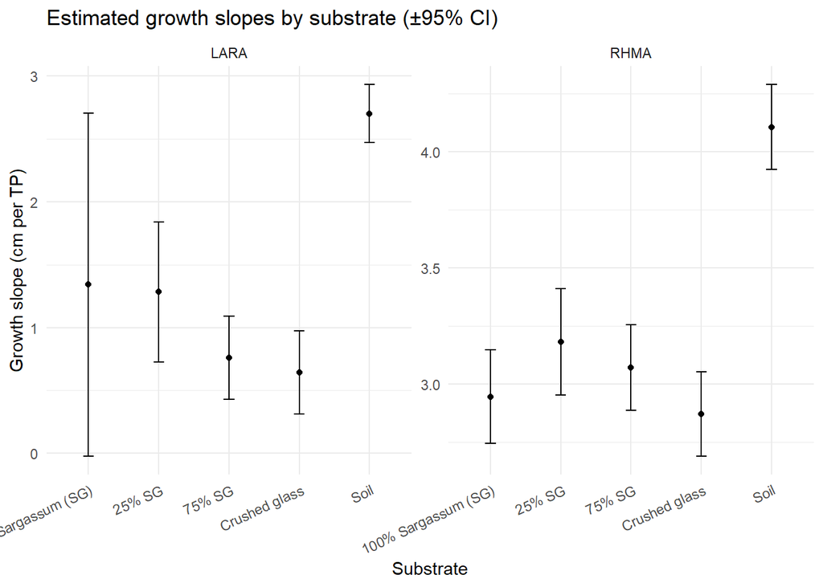

```r
# Simple slope plot with 95% CIs (one panel per species)
library(ggplot2)

ggplot(slope_tbl,
       aes(x = treatment_name, y = slope_cm_per_TP)) +
  geom_point(position = position_dodge(width = 0.6)) +
  geom_errorbar(aes(ymin = slope_LCL, ymax = slope_UCL),
                width = 0.15, position = position_dodge(width = 0.6)) +
  facet_wrap(~ Species, scales = "free_y") +
  labs(x = "Substrate", y = "Growth slope (cm per TP)",
       title = "Estimated growth slopes by substrate (±95% CI)") +
  theme_minimal() +
  theme(axis.text.x = element_text(angle = 25, hjust = 1))
```